# Effet de la taille de portefeuille sur les périodes de retour des sinistres

Kezhan SHI

31 mai 2014

# 1 Problématique

**Quand on a un scénario pour une entreprise dont l’exposition est connue, comment peut-on construire un scénario adapté pour une autre entreprise?**

On considère les hypothèses suivantes :

- le profil de risques des deux entreprises est similaire, ainsi on peut supposer que la distribution de la sévérité est identique
- la fréquence est proportionnelle à l’exposition.

# 2 Paramètres de modèle

## 2.1 Modèle de coût

On peut prendre la loi de Pareto:

```r
seuil=2e6
alpha=2.5
```

## 2.2 Modèle de Fréquence

On peut prendre la loi de Poisson ou la binomiale négative

- pour la loi de Poisson, on a besoin uniquement d’un paramètre qui caractérise la moyenne et la variance.

```r
f=10
```

- en pratique, on peut voir que la variance n’est pas forcément également à la moyenne, on peut adopter la loi binomiale négative

```r
mf=10
vf=16
# nb=rnbinom(1,size=mf^2/(vf-mf),mu=mf)
```

# 3 Analyse des périodes de retour

## 3.1 OEP 1

On considère un premier cas où la fréquence moyenne est de f.

```r
probs=seq(0,1,0.05)

pr=1/(1-probs) # Période de retour
FX=1+(log(probs)/f)

q2=qpareto(p=FX,seuil,alpha)
data.frame(probs=probs,pretour=pr,Quantiles1=q2)
```

```
##    probs   pretour Quantiles1
## 1   0.00  1.000000        NaN
## 2   0.05  1.052632    3239133
## 3   0.10  1.111111    3598684
## 4   0.15  1.176471    3888589
## 5   0.20  1.250000    4152984
## 6   0.25  1.333333    4408469
## 7   0.30  1.428571    4664266
## 8   0.35  1.538462    4927013
## 9   0.40  1.666667    5202555
## 10  0.45  1.818182    5496907
## 11  0.50  2.000000    5817010
## 12  0.55  2.222222    6171587
## 13  0.60  2.500000    6572354
## 14  0.65  2.857143    7036013
## 15  0.70  3.333333    7587889
## 16  0.75  4.000000    8269226
## 17  0.80  5.000000    9153691
## 18  0.85  6.666667   10391265
## 19  0.90 10.000000   12358303
## 20  0.95 20.000000   16481842
## 21  1.00       Inf        Inf
```

## 3.2 OEP 2

Ensuite, on considère que le exposition est deux fois plus grande, du coup, la fréquence moyenne est multipliée par 2.

```r
FX2=1+(log(probs)/f/2)
q2_2=qpareto(p=FX2,seuil,alpha)
data.frame(probs=probs,pretour=pr,Quantiles1=q2,Quantiles2=q2_2)
```

```
##    probs   pretour Quantiles1 Quantiles2
## 1   0.00  1.000000        NaN        NaN
## 2   0.05  1.052632    3239133    4274062
## 3   0.10  1.111111    3598684    4748492
## 4   0.15  1.176471    3888589    5131024
## 5   0.20  1.250000    4152984    5479896
## 6   0.25  1.333333    4408469    5817010
## 7   0.30  1.428571    4664266    6154536
## 8   0.35  1.538462    4927013    6501233
## 9   0.40  1.666667    5202555    6864812
## 10  0.45  1.818182    5496907    7253212
## 11  0.50  2.000000    5817010    7675591
## 12  0.55  2.222222    6171587    8143458
## 13  0.60  2.500000    6572354    8672273
## 14  0.65  2.857143    7036013    9284074
## 15  0.70  3.333333    7587889   10012279
## 16  0.75  4.000000    8269226   10911309
## 17  0.80  5.000000    9153691   12078368
## 18  0.85  6.666667   10391265   13711356
## 19  0.90 10.000000   12358303   16306879
## 20  0.95 20.000000   16481842   21747921
## 21  1.00       Inf        Inf        Inf
```

**On voit que pour les périodes de retour, il y a une certaine relation linéaire; mais cette relation est moins vraie pour les périodes de retour basses.**

## 3.3 Comparaison des périodes de retour basses

Afin d’avoir des intervalles plus réguliers sur les périodes de retour, on peut définir les probabilités à partir des périodes de retour. Les points rouges sont associés à l’entreprise 2 où l’exposition est 2 fois plus grande.

Dans un premier temps, on regarde les périodes de retour basses

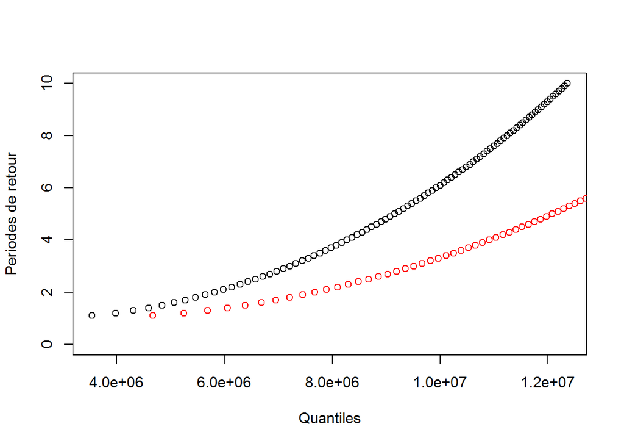

```r
pr=seq(0,10,0.1)

probs=1-1/pr

FX=1+(log(probs)/f)

q2=qpareto(p=FX,seuil,alpha)

FX2=1+(log(probs)/f/2)
q2_2=qpareto(p=FX2,seuil,alpha)

plot(q2,pr,xlab="Quantiles",ylab="Periodes de retour")
points(q2_2,pr,col=2)
```

Pour vérifier si les périodes de retour de l’entreprise 2 est plus fois plus petite, on peut diviser les périodes de retour de l’entreprise 1 par 2 (points verts) :

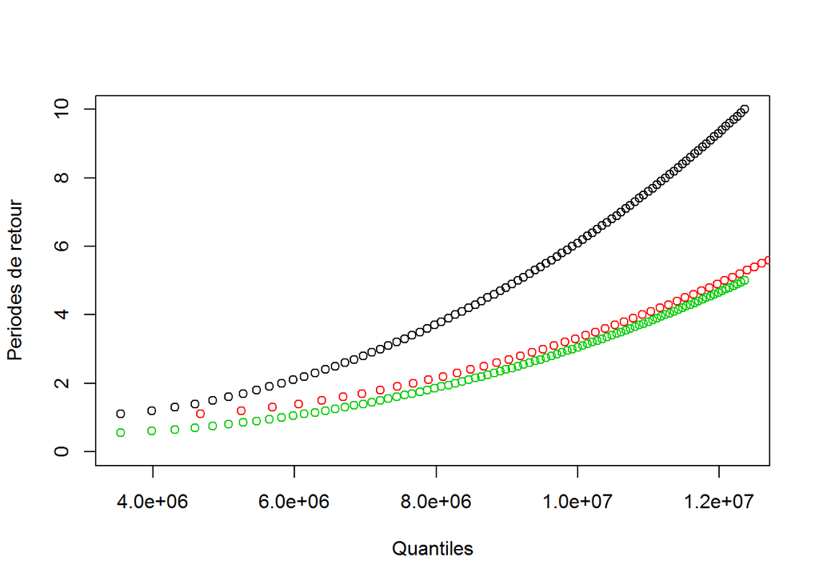

```r
plot(q2,pr,xlab="Quantiles",ylab="Periodes de retour")
points(q2_2,pr,col=2)
points(q2,pr/2,col=3)
```

## 3.4 Comparaison des périodes de retour hautes

Comme ce sont souvent les périodes de retour hautes qui nous intéressent, on peut se focaliser sur les périodes de retour hautes.

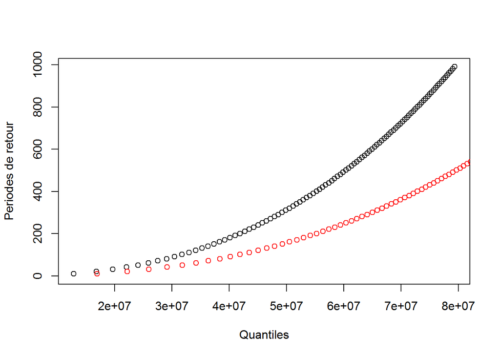

```r
pr=seq(1,1000,10)
probs=1-1/pr

FX=1+(log(probs)/f)

q2=qpareto(p=FX,seuil,alpha)

FX2=1+(log(probs)/f/2)
q2_2=qpareto(p=FX2,seuil,alpha)

plot(q2,pr,xlab="Quantiles",ylab="Periodes de retour")
points(q2_2,pr,col=2)
```

Pour vérifier si les périodes de retour de l’entreprise 2 est plus fois plus petite, on peut diviser les périodes de retour de l’entreprise 1 par 2 (points verts) :

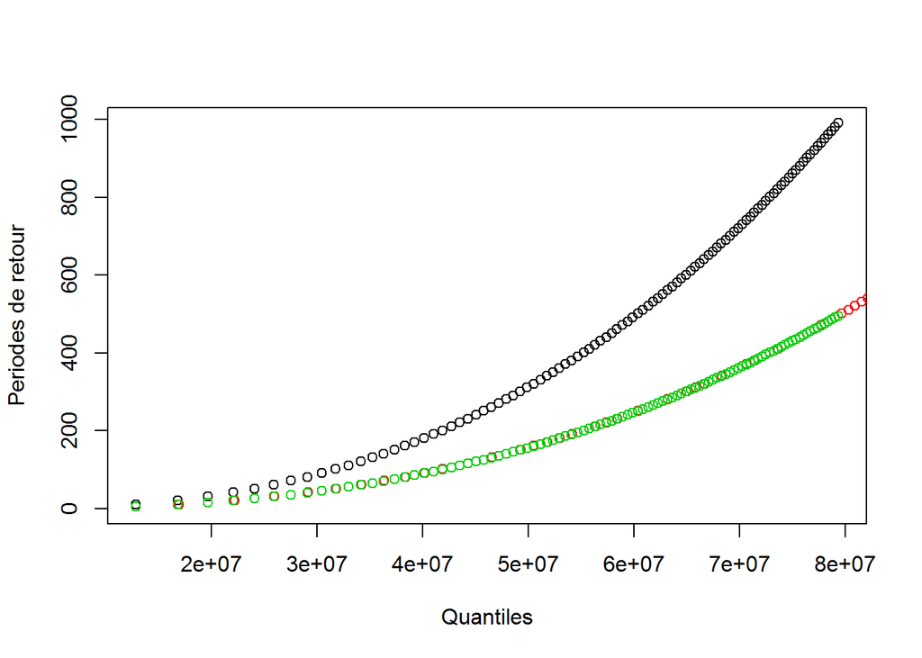

```r
plot(q2,pr,xlab="Quantiles",ylab="Periodes de retour")
points(q2_2,pr,col=2)
points(q2,pr/2,col=3)
```

On voit que les points rouges et verts sont sensiblement sur une même courbe.

# 4 Pour aller plus loin

Graphiquement, on voit que les périodes sont multipliées par 2 si l’exposition est divisée par 2, pour une loi de sévérité Pareto, et une loi de fréquence Poisson.

- Est-il possible de démontrer cette relation avec une formule fermée ?
- A-t-on une égalité exacte, ou approximative ?
- Est-ce vrai pour d’autres lois de sévérité ?
- Est-ce vrai pour une autre loi de fréquence ?